# 07_PCA.qmd

Group12

## Clear environment

```r
# | echo: true
# | eval: true

rm(list = ls())
```

## Load libraries

```r
# | echo: true
# | eval: true

library(tidyverse)
library(broom)
library(cowplot)
library(ggforce)
```

## Load data

```r
# | echo: true
# | eval: true

body_measurements <- read_tsv(file = "../data/PCOS_body_measurements_aug.tsv")
blood_measurements <- read_tsv(file = "../data/PCOS_blood_measurements_aug.tsv")
# verifying column names
colnames(blood_measurements)
```

```
##  [1] "patient_ID"               "PCOS_diagnosis"           "hemaglobin"               "betaHCG_1"
##  [5] "betaHCG_2"                "FSH"                      "LH"                       "FSH_LH_ratio"
##  [9] "TSH"                      "AMH"                      "PRL"                      "vitaminD3"
## [13] "PRG"                      "RBS"                      "cycle_or_pregnancy_stage"
```

## PCA analysis with blood measurements

Here we have filtered out all values that are NA.

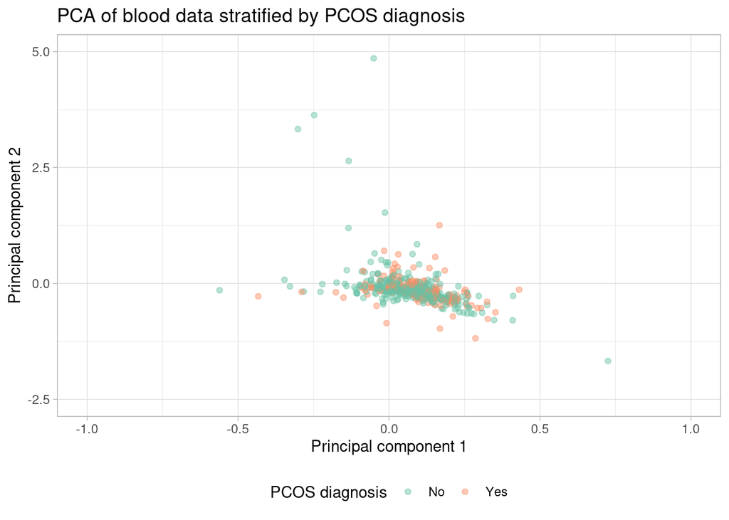

```r
# | echo: true
# | eval: true

# Remove rows with NAs
blood_measurements_no_na <- na.omit(blood_measurements)

# PCA plot for all numeric columns and scale the data
pca_fit <- blood_measurements_no_na |>
  select(where(is.numeric)) |>
  select(-patient_ID) |>
  prcomp(scale = TRUE)

# Add PCOS_diagnosis to the data and plot it
blood_PCA <- pca_fit |>
  augment(blood_measurements_no_na) |>
  ggplot(aes(.fittedPC1, .fittedPC2,
             color = PCOS_diagnosis)) +
  labs(title = "PCA of blood data stratified by PCOS diagnosis",
       x = "Principal component 1",
       y = "Principal component 2",
       color = "PCOS diagnosis") +
  geom_point(size = 1.5,
             alpha = 0.45) +
  scale_color_brewer(palette = "Set2") +
  theme_light() +
  theme(legend.position = "bottom") +
  xlim(-1, 1) +
  ylim(-2.5, 5)

blood_PCA
```

```r
# Saving the plot as a picture
ggsave(blood_PCA,
       filename = "../results/07_blood_PCA.png",
       device = "png",
       height = 20,
       width = 20,
       units = "cm")
```

### Rotation matrix in blood measurements

Testing what influences the components in the PCA plot, a rotation matrix is performed.

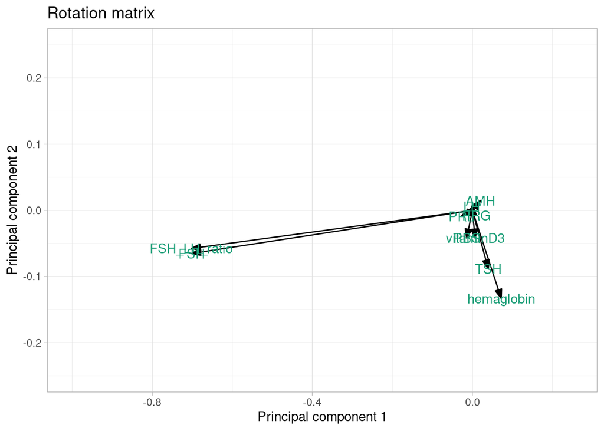

```r
# | echo: true
# | eval: true

# subtracting the rotation matrix
pca_fit |>
  tidy(matrix = "rotation")

# Make arrow style to be plotted
arrow_style <- arrow(angle = 20,
                     ends = "first",
                     type = "closed",
                     length = grid::unit(8, "pt"))

# plot rotation matrix
rotation_matrix_blood <- pca_fit |>
  tidy(matrix = "rotation") |>
  pivot_wider(names_from = "PC",
              names_prefix = "PC",
              values_from = "value") |>
  ggplot(aes(PC1, PC2)) +
  labs(title = "Rotation matrix",
       x = "Principal component 1",
       y = "Principal component 2")+
  geom_segment(xend = 0,
               yend = 0,
               arrow = arrow_style) +
  geom_text(aes(label = column),
            color = "#1B9E77") +
  theme_light() +
  theme(legend.position = "bottom") +
  xlim(-1,0.25) +
  ylim(-0.25, 0.25)

rotation_matrix_blood
```

```r
# Saving the plot as a picture
ggsave(rotation_matrix_blood,
       filename = "../results/07_rotation_matrix_blood.png",
       device = "png",
       height = 20,
       width = 20,
       units = "cm")
```

### Explaining variance in blood measurements

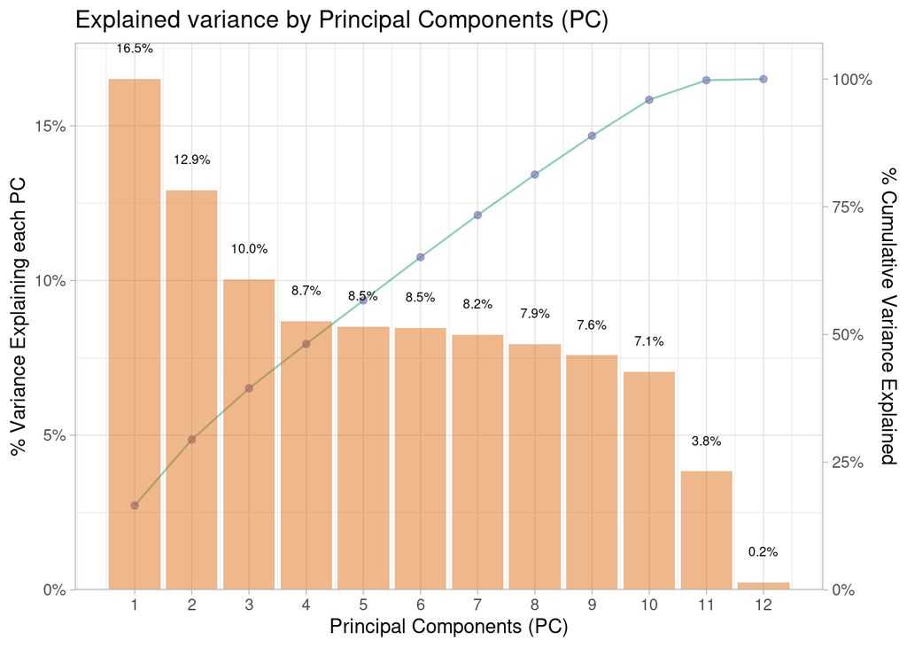

```r
# | echo: true
# | eval: true

eigenvalues <- pca_fit |>
  tidy(matrix = "eigenvalues")

max_cumulative <- max(eigenvalues$cumulative)
max_percent <- max(eigenvalues$percent)
transformation_co <- max_cumulative / max_percent

eigenvalues <- pca_fit |>
  tidy(matrix = "eigenvalues") |>
  select(cumulative) |>
  print()

# plotting
explained_variance_blood <- pca_fit |>
  tidy(matrix = "eigenvalues") |>
  ggplot(aes(PC, percent)) +
  geom_line(aes(y = cumulative / transformation_co),
            color = "#1B9E77",
            alpha = 0.5) +
  geom_point(aes(y = cumulative / transformation_co),
             color = "#7570B3",
             alpha = 0.6) +
  geom_col(fill = "#D95F02",
           alpha = 0.45) +
  geom_text(aes(label = scales::percent(percent,
                                        accuracy = 0.1),
                                        y = percent+0.01),
                                        color = "black",
                                        size = 2.5) +
  scale_x_continuous(breaks = 1:12) +
  scale_y_continuous(expand = expansion(mult = c(0, 0.01)),
                     labels = scales::percent_format(),
                     sec.axis = sec_axis(trans = ~.*transformation_co,
                        name = "% Cumulative Variance Explained",
                        labels = scales::percent_format())) +
  theme_light() +
  labs(y = "% Variance Explaining each PC",
       x = "Principal Components (PC)",
       title = "Explained variance by Principal Components (PC)") +
  theme(legend.position = "bottom")
explained_variance_blood
```

```r
# Saving the plot as a picture
ggsave(explained_variance_blood,
       filename = "../results/07_explained_variance_blood.png",
       device = "png",
       height = 20,
       width = 20,
       units = "cm")
```

### PCA analysis with FSH

Based on the rotation matrix, FSH may be interesting to test. Therefore we will investigate this further.

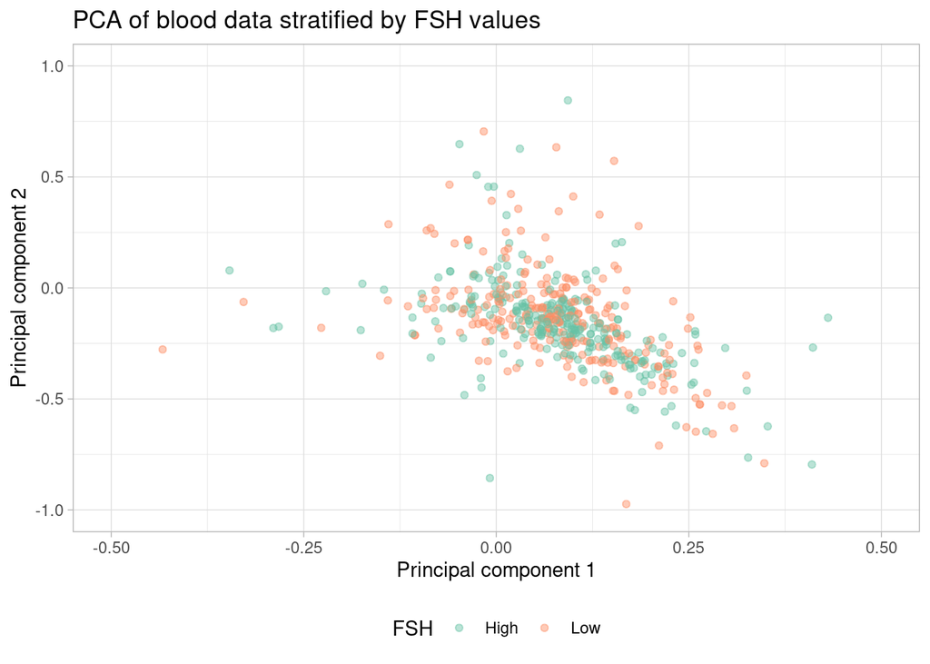

```r
# | echo: true
# | eval: true

# making FSH binary
blood_measurements_no_na <- blood_measurements_no_na |>
  mutate(FSH_binary = ifelse(FSH > median(FSH, na.rm = TRUE), "High", "Low"))

# make PCA plot with FSH
FSH_PCA <- pca_fit |>
  augment(blood_measurements_no_na) |>
  ggplot(aes(.fittedPC1, .fittedPC2, color = FSH_binary)) +
  labs(title = "PCA of blood data stratified by FSH values",
       x = "Principal component 1",
       y = "Principal component 2",
       color = "FSH") +
  theme_light() +
  scale_color_brewer(palette = "Set2") +
  theme(legend.position = "bottom") +
  geom_point(size = 1.5,
             alpha = 0.45) +
  xlim(-0.5, 0.5) +
  ylim(-1, 1)

FSH_PCA
```

```r
# Saving the plot as a picture
ggsave(FSH_PCA,
       filename = "../results/07_FSH_PCA.png",
       device = "png",
       height = 20,
       width = 20,
       units = "cm")
```

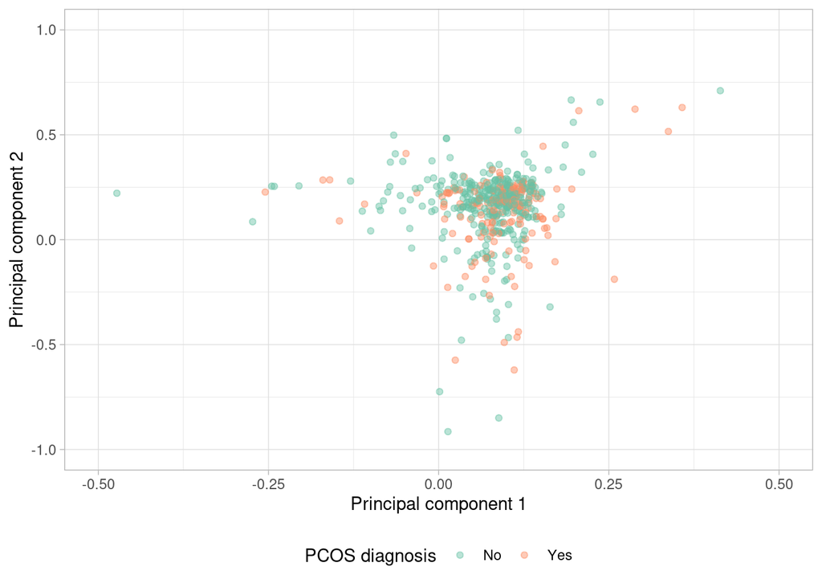

```r
# | echo: true
# | eval: true

# removing rows containing NAs
blood_measurements_no_na <- na.omit(blood_measurements)

# PCA plot for numeric columns and scale the data
pca_fit <- blood_measurements_no_na |>
  select(where(is.numeric)) |>
  select(-patient_ID, -vitaminD3, -RBS, -hemaglobin) |>
  prcomp(scale = TRUE)

# adding PCOS diagnosis to the data and plotting the PCA
blood_not_hormes_PCA <- pca_fit |>
  augment(blood_measurements_no_na) |>
  ggplot(aes(.fittedPC1, .fittedPC2,
             color = PCOS_diagnosis)) +
  labs(x = "Principal component 1",
       y = "Principal component 2",
       color = "PCOS diagnosis") +
  geom_point(size = 1.5,
             alpha = 0.45) +
  theme_light() +
  scale_color_brewer(palette = "Set2") +
  theme(legend.position = "bottom") +
  xlim(-0.5, 0.5) +
  ylim(-1, 1)

blood_not_hormes_PCA
```

```r
# Saving the plot as a picture
ggsave(blood_not_hormes_PCA,
       filename = "../results/07_blood_not_hormes_PCA.png",
       device = "png",
       height = 20,
       width = 20,
       units = "cm")
```

## PCA analysis with body measurements

Next analysis, all values that are numeric values in the body measurements data set will be tested

Here we have filtered out all values that are NA.

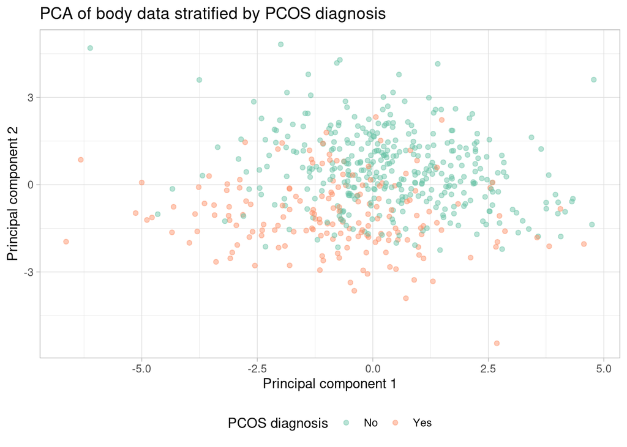

```r
# | echo: true
# | eval: true

# Remove rows with NAs
body_measurements_no_na <- na.omit(body_measurements)

# PCA plot for all numeric columns and scale the data
pca_fit_2 <- body_measurements_no_na |>
  select(where(is.numeric)) |>
  select(-patient_ID) |>
  prcomp(scale = TRUE)

# Add PCOS_diagnosis to the data and plot it
body_PCA <- pca_fit_2 |>
  augment(body_measurements_no_na) |>
  ggplot(aes(.fittedPC1, .fittedPC2,
             color = PCOS_diagnosis)) +
  labs(title = "PCA of body data stratified by PCOS diagnosis",
       x = "Principal component 1",
       y = "Principal component 2",
       color = "PCOS diagnosis") +
  geom_point(size = 1.5,
             alpha = 0.45) +
  theme_light() +
  scale_color_brewer(palette = "Set2") +
  theme(legend.position = "bottom")

body_PCA
```

```r
# Saving the plot as a picture
ggsave(body_PCA,
       filename = "../results/07_body_PCA.png",
       device = "png",
       height = 20,
       width = 20,
       units = "cm")
```

### Rotation matrix for body measurements

Testing what influences the components in the PCA plot, a rotation matrix is performed.

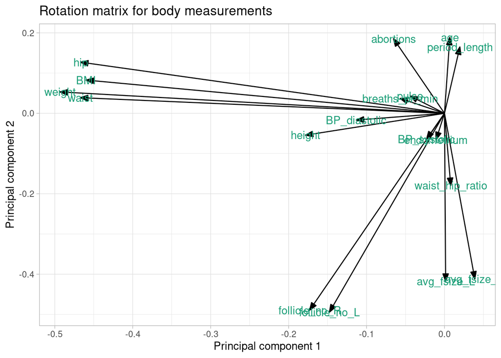

```r
# | echo: true
# | eval: true

# subtracting the rotation matrix
pca_fit_2 |>
  tidy(matrix = "rotation")

# Make arrow style to be plotted
arrow_style <- arrow(angle = 20,
                     ends = "first",
                     type = "closed",
                     length = grid::unit(8, "pt"))

# plot rotation matrix
rotation_matrix_body <- pca_fit_2 |>
  tidy(matrix = "rotation") |>
  pivot_wider(names_from = "PC",
              names_prefix = "PC",
              values_from = "value") |>
  ggplot(aes(PC1, PC2)) +
  labs(title = "Rotation matrix for body measurements",
       x = "Principal component 1",
       y = "Principal component 2") +
  geom_segment(xend = 0,
               yend = 0,
               arrow = arrow_style) +
  geom_text(aes(label = column),
            color = "#1B9E77") +
  theme_light()

rotation_matrix_body
```

```r
# Saving the plot as a picture
ggsave(rotation_matrix_body,
       filename = "../results/07_rotation_matrix_body.png",
       device = "png",
       height = 20,
       width = 20,
       units = "cm")
```

### Explaining variance in body measurements

[figure not shown]

```r
# | echo: true
# | eval: true

eigenvalues_BM <- pca_fit_2 |>
  tidy(matrix = "eigenvalues")

max_cumulative_BM <- max(eigenvalues_BM$cumulative)
max_percent_BM <- max(eigenvalues_BM$percent)
transformation_co_BM <- max_cumulative_BM / max_percent_BM

eigenvalues_BM <- pca_fit_2 |>
  tidy(matrix = "eigenvalues") |>
  select(cumulative) |>
  print()

# plotting
explained_variance_body <- pca_fit_2 |>
  tidy(matrix = "eigenvalues") |>
  ggplot(aes(PC, percent)) +
  geom_line(aes(y = cumulative / transformation_co_BM),
            color = "#1B9E77") +
  geom_point(aes(y = cumulative / transformation_co_BM),
             color = "#7570B3") +
  geom_col(fill = "#D95F02",
           alpha = 0.45) +
  geom_text(aes(label = scales::percent(percent,
                                        accuracy = 0.1),
                y = percent+0.01),
                color = "black",
                size = 2.5) +
  scale_x_continuous(breaks = 1:18) +
  scale_y_continuous(expand = expansion(mult = c(0, 0.01)),
                     labels = scales::percent_format(),
                      sec.axis = sec_axis(trans = ~.*transformation_co,
                                          name = "% Cumulative Variance Explained",
                                          labels = scales::percent_format())) +
  theme_minimal_hgrid(12) +
  labs(y = "% Variance Explaining each PC",
       x = "Principal Components (PC)",
       title = "Explained variance by Principal Components (PC) for body measurments")

explained_variance_body
```

```r
# Saving the plot as a picture
ggsave(explained_variance_body,
       filename = "../results/07_explained_variance_body.png",
       device = "png",
       height = 20,
       width = 20,
       units = "cm")
```

### PCA analysis with follicles

From the rotation matrix plot, follicles seems to be important. Therefore we will zoom in on this even further.

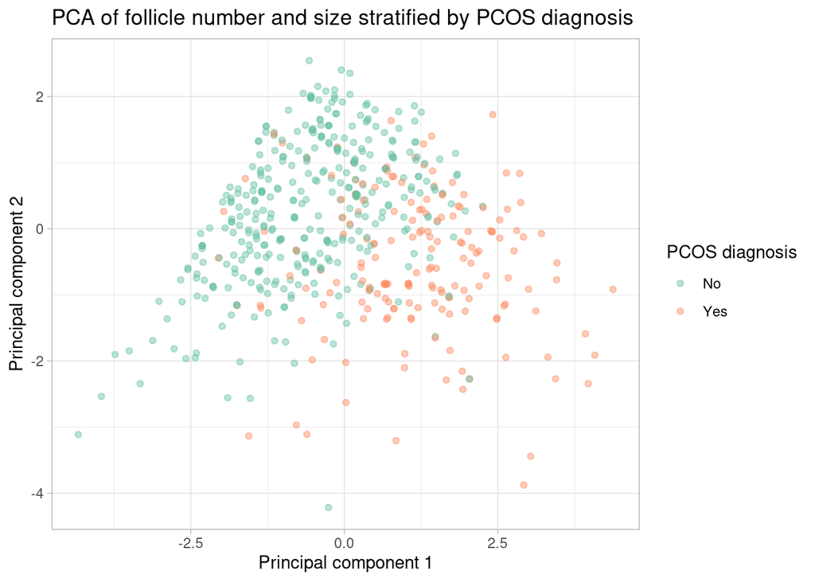

```r
# | echo: true
# | eval: true

# PCA plot for all numeric columns and scale the data
pca_fit_3 <- body_measurements_no_na |>
  select(where(is.numeric)) |>
  select(follicle_no_R, follicle_no_L, avg_fsize_R, avg_fsize_L) |>
  prcomp(scale = TRUE)

# Add PCOS_diagnosis to the data and plot it
follicle_PCA <- pca_fit_3 |>
  augment(body_measurements_no_na) |>
  ggplot(aes(.fittedPC1, .fittedPC2,
             color = PCOS_diagnosis)) +
  labs(title = "PCA of follicle number and size stratified by PCOS diagnosis",
       x = "Principal component 1",
       y = "Principal component 2",
       color = "PCOS diagnosis") +
  geom_point(size = 1.5,
             alpha = 0.45) +
  theme_light() +
  scale_color_brewer(palette = "Set2")

follicle_PCA
```

```r
# Saving the plot as a picture
ggsave(follicle_PCA,
       filename = "../results/07_follicle_PCA.png",
       device = "png",
       height = 20,
       width = 20,
       units = "cm")
```

### PCA analysis with obesity factor

Furthermore, we want to examine the impact of obesity factors, such as BMI, weight and so.

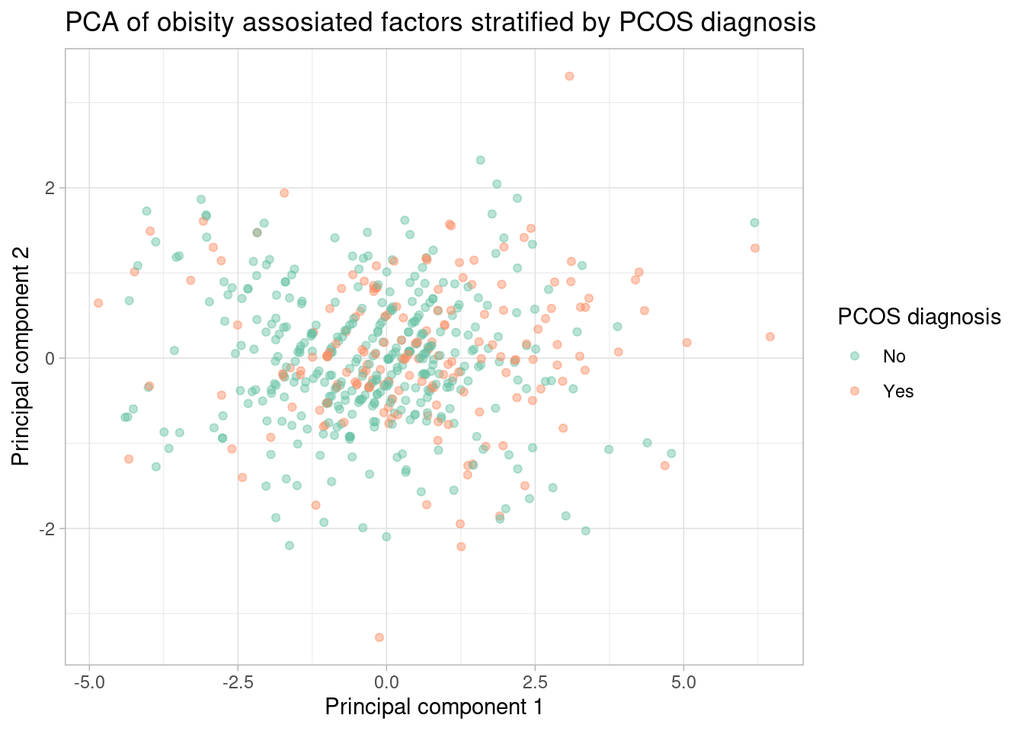

```r
# | echo: true
# | eval: true

# PCA plot for obisity factor
pca_fit_4 <- body_measurements_no_na |>
  select(where(is.numeric)) |>
  select(weight, BMI, hip, waist) |>
  prcomp(scale = TRUE)

# Add PCOS_diagnosis to the data and plot it
obs_PCA <- pca_fit_4 |>
  augment(body_measurements_no_na) |>
  ggplot(aes(.fittedPC1, .fittedPC2,
             color = PCOS_diagnosis)) +
  labs(title = "PCA of obisity assosiated factors stratified by PCOS diagnosis",
       x = "Principal component 1",
       y = "Principal component 2",
       color = "PCOS diagnosis") +
  geom_point(size = 1.5,
             alpha = 0.45) +
  theme_light() +
  scale_color_brewer(palette = "Set2")

obs_PCA
```

```r
# Saving the plot as a picture
ggsave(obs_PCA,
       filename = "../results/07_obs_PCA.png",
       device = "png",
       height = 20,
       width = 20,
       units = "cm")
```